# Homework Assignment #4: Collinearity & Generalized Linear Models

EDUC/PSY 7610: Regression Analysis

Instructor: Jamison Fargo, PhD

May 01, 2023

Please complete the following exercises. You must include the code (as brief as possible) that was used to run each exercise along with the results. You may work in groups of 2 or 3 if you like, but each student should submit their own homework assignment. You will be able to upload your completed assignment to CANVAS. You may complete these exercises using BlueSky or R Studio (eg, script or R Markdown).

```r
library(tidyverse)
library(car)
```

```r
library(carData)
library(ggpubr)
library(jtools)
library(broom)
library(cowplot)
library(lmtest)
library(gtsummary)
library(apaTables)
library(ppcor)
library(readxl)
library(dplyr)
library(emmeans)
library(ggstance)
library(broom.mixed)
library(sjPlot)
library(olsrr)
library(stargazer)
library(pls)
library(glmnet)
library(performance)
library(writexl)
library(MASS)
library(pscl)
library(scatterPlotMatrix)
library(nnet)
library(brant)
library(reshape)
```

### Part I: Collinearity

Use data from a sample of 500 individuals with left hemisphere brain injury (`Npsych.xlsx`) for the following problems.

```r
npsych <- read_excel("C:\\Users\\Rifatul Islam Himel\\Downloads\\A4 - Npsych.xlsx")
head(npsych)
```

```
## # A tibble: 6 × 6
##     vmt   viq   vnt    wf   dur   aoo
##   <dbl> <dbl> <dbl> <dbl> <dbl> <dbl>
## 1  4.63  3.57  3.49  3.15  2.63  3.14
## 2  4.34  2.42  2.58  2.57  4.09  4.48
## 3  2.84  2.31  2.10  2.35  2.98  2.39
## 4  5.35  2.18  1.74  2.14  2.34  2.85
## 5  3.70  3.46  3.16  3.29  4.53  4.46
## 6  7.88  2.90  2.80  2.92  1.66  1.16
```

1. Create and present a scatterplot matrix of all variables in this data set. What variables would you predict will have collinearity issues with each other?

```r
library(GGally)
```

```r
library(scatterPlotMatrix)
scatterPlotMatrix(npsych,
                  corrPlotType = "Text",
                  continuousCS = "YlOrRd",
                  distribType = 1,
                  regressionType = 2
)
```

[interactive chart not shown]

From the scatterplot matrix, we can see that verbal IQ, verbal naming ability and word fluency ability are highly correlated (all about 0.95). Moreover, duration since injury and age of injury onset are highly correlated (0.91).  
2. Conduct a multiple regression analysis of verbal memory test scores (`vmt`) as the dependent variable on a measure of verbal IQ (`viq`), verbal naming ability (`vnt`), word fluency ability (`wf`), duration since injury (`dur`), and age of injury onset (`aoo`).

```r
lm.1 <- lm(vmt ~ viq+vnt+wf+dur+aoo, data=npsych)
summ(lm.1)
```

```
## MODEL INFO:
## Observations: 500
## Dependent Variable: vmt
## Type: OLS linear regression
##
## MODEL FIT:
## F(5,494) = 140.68, p = 0.00
## R² = 0.59
## Adj. R² = 0.58
##
## Standard errors: OLS
## ------------------------------------------------
##                      Est.   S.E.   t val.      p
## ----------------- ------- ------ -------- ------
## (Intercept)          1.10   0.31     3.57   0.00
## viq                  0.43   0.25     1.75   0.08
## vnt                  0.65   0.27     2.42   0.02
## wf                   0.61   0.26     2.36   0.02
## dur                 -0.51   0.17    -3.00   0.00
## aoo                 -0.19   0.17    -1.09   0.28
## ------------------------------------------------
```

3. Produce a formatted summary table of this regression model using `tbl_regression` from the `gtsummary` package.

```r
tbl_initial1 <- tbl_regression(lm.1,
                            intercept = TRUE,
                            label = list(viq ~ "verbal IQ",
                                         vnt ~ "verbal naming ability",
                                         wf  ~ "word fluency ability",
                                         dur ~ "duration since injury",
                                         aoo ~ "age of injury onset"),
                            pvalue_fun = function(x) style_pvalue(x, digits = 3),
                            estimate_fun = function(x) style_sigfig(x, digits = 2)) %>%
  add_glance_table(include = c(nobs, adj.r.squared, statistic, df, df.residual, p.value),
                   label = list(nobs ~ "N",
                                statistic ~ "F-statistic", df ~ "df_reg", df.residual ~ "df_res",
                                p.value = "p-value")
  )
tbl_initial1
```

| **Characteristic** | **Beta** | **95% CI**<sup>1</sup> | **p-value** |
| --- | --- | --- | --- |
| (Intercept) | 1.1 | 0.50, 1.7 | <0.001 |
| verbal IQ | 0.43 | -0.05, 0.92 | 0.081 |
| verbal naming ability | 0.65 | 0.12, 1.2 | 0.016 |
| word fluency ability | 0.61 | 0.10, 1.1 | 0.019 |
| duration since injury | -0.51 | -0.84, -0.17 | 0.003 |
| age of injury onset | -0.19 | -0.52, 0.15 | 0.278 |
| N | 500 |  |  |
| Adjusted R² | 0.583 |  |  |
| F-statistic | 141 |  |  |
| df_reg | 5 |  |  |
| df_res | 494 |  |  |
| p-value | <0.001 |  |  |

<sup>1</sup> CI = Confidence Interval

4. Check collinearity diagnostics for this model, especially VIF and the VDPs. Look at VDPs for any condition indices above 20. What are the collinearity issues (ie, what variables are collinear)?

```r
olsrr::ols_coll_diag(lm.1)
```

```
## Tolerance and Variance Inflation Factor
## ---------------------------------------
##   Variables  Tolerance       VIF
## 1       viq 0.07431486 13.456260
## 2       vnt 0.06289018 15.900733
## 3        wf 0.06997760 14.290288
## 4       dur 0.17112537  5.843669
## 5       aoo 0.17088064  5.852038
##
##
## Eigenvalue and Condition Index
## ------------------------------
##    Eigenvalue Condition Index    intercept          viq          vnt
## 1 5.674955936        1.000000 0.0016350372 2.425444e-04 2.089281e-04
## 2 0.259612867        4.675393 0.0021652509 4.544317e-03 4.018090e-03
## 3 0.045382427       11.182461 0.9905800958 3.150448e-03 3.499994e-03
## 4 0.009783573       24.084216 0.0038497443 4.196901e-05 3.796118e-06
## 5 0.005619817       31.777531 0.0014268057 8.683475e-01 3.198222e-02
## 6 0.004645380       34.951888 0.0003430661 1.236733e-01 9.602870e-01
##             wf          dur          aoo
## 1 0.0002268932 5.379911e-04 0.0005299481
## 2 0.0040448144 1.990906e-02 0.0203180869
## 3 0.0037515666 2.847344e-02 0.0201049674
## 4 0.0004748850 9.507795e-01 0.9572184695
## 5 0.5084937072 2.534512e-04 0.0013883696
## 6 0.4830081335 4.657544e-05 0.0004401585
```

```r
viftol1 <- olsrr::ols_vif_tol(lm.1)
viftol1
```

```
##   Variables  Tolerance       VIF
## 1       viq 0.07431486 13.456260
## 2       vnt 0.06289018 15.900733
## 3        wf 0.06997760 14.290288
## 4       dur 0.17112537  5.843669
## 5       aoo 0.17088064  5.852038
```

```r
print(viftol1$VIF, digits = 3)
```

```
## [1] 13.46 15.90 14.29  5.84  5.85
```

```r
collinstats <- olsrr::ols_coll_diag(lm.1)
collinstats
```

```
## Tolerance and Variance Inflation Factor
## ---------------------------------------
##   Variables  Tolerance       VIF
## 1       viq 0.07431486 13.456260
## 2       vnt 0.06289018 15.900733
## 3        wf 0.06997760 14.290288
## 4       dur 0.17112537  5.843669
## 5       aoo 0.17088064  5.852038
##
##
## Eigenvalue and Condition Index
## ------------------------------
##    Eigenvalue Condition Index    intercept          viq          vnt
## 1 5.674955936        1.000000 0.0016350372 2.425444e-04 2.089281e-04
## 2 0.259612867        4.675393 0.0021652509 4.544317e-03 4.018090e-03
## 3 0.045382427       11.182461 0.9905800958 3.150448e-03 3.499994e-03
## 4 0.009783573       24.084216 0.0038497443 4.196901e-05 3.796118e-06
## 5 0.005619817       31.777531 0.0014268057 8.683475e-01 3.198222e-02
## 6 0.004645380       34.951888 0.0003430661 1.236733e-01 9.602870e-01
##             wf          dur          aoo
## 1 0.0002268932 5.379911e-04 0.0005299481
## 2 0.0040448144 1.990906e-02 0.0203180869
## 3 0.0037515666 2.847344e-02 0.0201049674
## 4 0.0004748850 9.507795e-01 0.9572184695
## 5 0.5084937072 2.534512e-04 0.0013883696
## 6 0.4830081335 4.657544e-05 0.0004401585
```

VIP of verbal IQ , verbal naming ability, and word fluency ability are more than 10.

VDPs for any condition indices above 20 here are dur, aoo; and viq, wf. Ie last CI, vnt, wf are pretty high with high CI. However, wf is within (0.4-0.5). So according to lecture notes, this is a possible collinear issue. But There are definite collinear issues in dur, aoo and viq, wf.

5. Compute a correlation matrix for the variables that are involved in the collinearity problems.

```r
cor(npsych[,c("viq","vnt","wf","dur","aoo")])
```

```
##             viq          vnt           wf          dur         aoo
## viq  1.00000000  0.954173442  0.948748998 -0.010561447 -0.03440765
## vnt  0.95417344  1.000000000  0.956826762 -0.008341845 -0.03193818
## wf   0.94874900  0.956826762  1.000000000  0.004745215 -0.01743092
## dur -0.01056145 -0.008341845  0.004745215  1.000000000  0.91018228
## aoo -0.03440765 -0.031938181 -0.017430920  0.910182285  1.00000000
```

6. As a first step in attempting to alleviate collinearity problems, combine all verbal-related predictors into a “Verbal Composite Score” variable called (`verbal`) by: + Transforming `viq`, `vnt`, and `wf` into z-scores; + Computing the average of these z-score variables for each participant to create the new (`verbal`) variable.

```r
npsych$viq_z <- scale(npsych$viq)
npsych$vnt_z <- scale(npsych$vnt)
npsych$wf_z <- scale(npsych$wf)

npsych$verbal <- rowMeans(npsych[, c("viq_z", "vnt_z", "wf_z")])
head(npsych)
```

```
## # A tibble: 6 × 10
##     vmt   viq   vnt    wf   dur   aoo viq_z[,1] vnt_z[,1] wf_z[,1] verbal
##   <dbl> <dbl> <dbl> <dbl> <dbl> <dbl>     <dbl>     <dbl>    <dbl>  <dbl>
## 1  4.63  3.57  3.49  3.15  2.63  3.14     0.493     0.422    0.110  0.342
## 2  4.34  2.42  2.58  2.57  4.09  4.48    -0.582    -0.418   -0.443 -0.481
## 3  2.84  2.31  2.10  2.35  2.98  2.39    -0.691    -0.866   -0.648 -0.735
## 4  5.35  2.18  1.74  2.14  2.34  2.85    -0.807    -1.21    -0.840 -0.951
## 5  3.70  3.46  3.16  3.29  4.53  4.46     0.391     0.116    0.239  0.249
## 6  7.88  2.90  2.80  2.92  1.66  1.16    -0.133    -0.220   -0.106 -0.153
```

7. Then, include the new `verbal` variable as a predictor of `vmt` in the following 3 separate regression analyses: + With also both `dur` centered and `aoo` centered as predictors; + With also only `dur` centered as a predictor; + With also only `aoo` centered as a predictor.

```r
npsych$dur_centered <- scale(npsych$dur, center = TRUE, scale = FALSE)
npsych$aoo_centered <- scale(npsych$aoo, center = TRUE, scale = FALSE)


lm.2 <- lm(vmt ~ verbal + dur_centered + aoo_centered, data = npsych)
summ(lm.2)
```

```
## MODEL INFO:
## Observations: 500
## Dependent Variable: vmt
## Type: OLS linear regression
##
## MODEL FIT:
## F(3,496) = 235.18, p = 0.00
## R² = 0.59
## Adj. R² = 0.58
##
## Standard errors: OLS
## -------------------------------------------------
##                       Est.   S.E.   t val.      p
## ------------------ ------- ------ -------- ------
## (Intercept)           4.19   0.07    58.15   0.00
## verbal                1.80   0.07    24.57   0.00
## dur_centered         -0.51   0.17    -3.01   0.00
## aoo_centered         -0.18   0.17    -1.08   0.28
## -------------------------------------------------
```

```r
lm.3 <- lm(vmt ~ verbal + dur_centered, data = npsych)
summ(lm.3)
```

```
## MODEL INFO:
## Observations: 500
## Dependent Variable: vmt
## Type: OLS linear regression
##
## MODEL FIT:
## F(2,497) = 352.07, p = 0.00
## R² = 0.59
## Adj. R² = 0.58
##
## Standard errors: OLS
## -------------------------------------------------
##                       Est.   S.E.   t val.      p
## ------------------ ------- ------ -------- ------
## (Intercept)           4.19   0.07    58.14   0.00
## verbal                1.81   0.07    24.67   0.00
## dur_centered         -0.67   0.07    -9.64   0.00
## -------------------------------------------------
```

```r
lm.4 <- lm(vmt ~ verbal + aoo_centered, data = npsych)
summ(lm.4)
```

```
## MODEL INFO:
## Observations: 500
## Dependent Variable: vmt
## Type: OLS linear regression
##
## MODEL FIT:
## F(2,497) = 342.72, p = 0.00
## R² = 0.58
## Adj. R² = 0.58
##
## Standard errors: OLS
## -------------------------------------------------
##                       Est.   S.E.   t val.      p
## ------------------ ------- ------ -------- ------
## (Intercept)           4.19   0.07    57.69   0.00
## verbal                1.79   0.07    24.26   0.00
## aoo_centered         -0.65   0.07    -9.15   0.00
## -------------------------------------------------
```

8. Compute collinearity diagnostic statistics for each model to determine what collinearity issues remain, if any. How does the overall model fit for these 3 models compare to one another (ie, how different are they)? Which of these 3 models would you choose as a final model? Why?

```r
olsrr::ols_coll_diag(lm.2)
```

```
## Tolerance and Variance Inflation Factor
## ---------------------------------------
##      Variables Tolerance      VIF
## 1       verbal 0.9966177 1.003394
## 2 dur_centered 0.1711257 5.843659
## 3 aoo_centered 0.1709919 5.848232
##
##
## Eigenvalue and Condition Index
## ------------------------------
##   Eigenvalue Condition Index intercept       verbal dur_centered aoo_centered
## 1 1.91078625        1.000000         0 0.0003456957 0.0447280804 4.473527e-02
## 2 1.00000000        1.382312         1 0.0000000000 0.0000000000 0.000000e+00
## 3 0.99970139        1.382518         0 0.9959203419 0.0001661353 4.723283e-06
## 4 0.08951236        4.620240         0 0.0037339624 0.9551057844 9.552600e-01
```

```r
viftol2 <- olsrr::ols_vif_tol(lm.2)
viftol2
```

```
##      Variables Tolerance      VIF
## 1       verbal 0.9966177 1.003394
## 2 dur_centered 0.1711257 5.843659
## 3 aoo_centered 0.1709919 5.848232
```

```r
print(viftol2$VIF, digits = 3)
```

```
## [1] 1.00 5.84 5.85
```

```r
collinstats2 <- olsrr::ols_coll_diag(lm.2)
collinstats2
```

```
## Tolerance and Variance Inflation Factor
## ---------------------------------------
##      Variables Tolerance      VIF
## 1       verbal 0.9966177 1.003394
## 2 dur_centered 0.1711257 5.843659
## 3 aoo_centered 0.1709919 5.848232
##
##
## Eigenvalue and Condition Index
## ------------------------------
##   Eigenvalue Condition Index intercept       verbal dur_centered aoo_centered
## 1 1.91078625        1.000000         0 0.0003456957 0.0447280804 4.473527e-02
## 2 1.00000000        1.382312         1 0.0000000000 0.0000000000 0.000000e+00
## 3 0.99970139        1.382518         0 0.9959203419 0.0001661353 4.723283e-06
## 4 0.08951236        4.620240         0 0.0037339624 0.9551057844 9.552600e-01
```

```r
olsrr::ols_coll_diag(lm.3)
```

```
## Tolerance and Variance Inflation Factor
## ---------------------------------------
##      Variables Tolerance      VIF
## 1       verbal  0.999977 1.000023
## 2 dur_centered  0.999977 1.000023
##
##
## Eigenvalue and Condition Index
## ------------------------------
##   Eigenvalue Condition Index intercept    verbal dur_centered
## 1  1.0047947        1.000000         0 0.4976027    0.4976027
## 2  1.0000000        1.002394         1 0.0000000    0.0000000
## 3  0.9952053        1.004806         0 0.5023973    0.5023973
```

```r
viftol3 <- olsrr::ols_vif_tol(lm.3)
viftol3
```

```
##      Variables Tolerance      VIF
## 1       verbal  0.999977 1.000023
## 2 dur_centered  0.999977 1.000023
```

```r
print(viftol3$VIF, digits = 3)
```

```
## [1] 1 1
```

```r
collinstats3 <- olsrr::ols_coll_diag(lm.3)
collinstats3
```

```
## Tolerance and Variance Inflation Factor
## ---------------------------------------
##      Variables Tolerance      VIF
## 1       verbal  0.999977 1.000023
## 2 dur_centered  0.999977 1.000023
##
##
## Eigenvalue and Condition Index
## ------------------------------
##   Eigenvalue Condition Index intercept    verbal dur_centered
## 1  1.0047947        1.000000         0 0.4976027    0.4976027
## 2  1.0000000        1.002394         1 0.0000000    0.0000000
## 3  0.9952053        1.004806         0 0.5023973    0.5023973
```

```r
olsrr::ols_coll_diag(lm.4)
```

```
## Tolerance and Variance Inflation Factor
## ---------------------------------------
##      Variables Tolerance      VIF
## 1       verbal 0.9991951 1.000806
## 2 aoo_centered 0.9991951 1.000806
##
##
## Eigenvalue and Condition Index
## ------------------------------
##   Eigenvalue Condition Index intercept    verbal aoo_centered
## 1  1.0283712        1.000000         0 0.4858144    0.4858144
## 2  1.0000000        1.014086         1 0.0000000    0.0000000
## 3  0.9716288        1.028785         0 0.5141856    0.5141856
```

```r
viftol4 <- olsrr::ols_vif_tol(lm.4)
viftol4
```

```
##      Variables Tolerance      VIF
## 1       verbal 0.9991951 1.000806
## 2 aoo_centered 0.9991951 1.000806
```

```r
print(viftol4$VIF, digits = 3)
```

```
## [1] 1 1
```

```r
collinstats4 <- olsrr::ols_coll_diag(lm.4)
collinstats4
```

```
## Tolerance and Variance Inflation Factor
## ---------------------------------------
##      Variables Tolerance      VIF
## 1       verbal 0.9991951 1.000806
## 2 aoo_centered 0.9991951 1.000806
##
##
## Eigenvalue and Condition Index
## ------------------------------
##   Eigenvalue Condition Index intercept    verbal aoo_centered
## 1  1.0283712        1.000000         0 0.4858144    0.4858144
## 2  1.0000000        1.014086         1 0.0000000    0.0000000
## 3  0.9716288        1.028785         0 0.5141856    0.5141856
```

```r
pcr.lm.2 <- pcr(vmt ~ verbal + dur_centered + aoo_centered, data = npsych)
summary(pcr.lm.2)
```

```
## Data:    X dimension: 500 3
##  Y dimension: 500 1
## Fit method: svdpc
## Number of components considered: 3
## TRAINING: % variance explained
##      1 comps  2 comps  3 comps
## X     65.495    96.93   100.00
## vmt    9.094    58.62    58.72
```

```r
pcr.lm.3 <- pcr(vmt ~ verbal + dur_centered, data = npsych)
summary(pcr.lm.3)
```

```
## Data:    X dimension: 500 2
##  Y dimension: 500 1
## Fit method: svdpc
## Number of components considered: 2
## TRAINING: % variance explained
##      1 comps  2 comps
## X     52.413   100.00
## vmt    9.925    58.62
```

```r
pcr.lm.4 <- pcr(vmt ~ verbal + aoo_centered, data = npsych)
summary(pcr.lm.4)
```

```
## Data:    X dimension: 500 2
##  Y dimension: 500 1
## Fit method: svdpc
## Number of components considered: 2
## TRAINING: % variance explained
##      1 comps  2 comps
## X      52.38   100.00
## vmt    23.54    57.97
```

Based on the VIF, CIs, VDP and PCA regression, we can see how overall model fit for these 3 models compare to one another. In model 2, we need 3 components to explain 58.72% whereas third model needs only 2 components that explaines 58.62%. If I check CIs and VDP, third model is probably the best compared to others.Therefore, I would choose the third model (verbal and dur_centered predicting vmt).

9. Present the results of the final model you choose in a formatted regression table using `tbl_regression` from the `gtsummary` package. How does the overall fit of the final model differ from the initial model tested?

```r
tbl_final <- tbl_regression(lm.3,
                            intercept = TRUE,
                            label = list(verbal ~ "Verbal Composite Score",
                                         dur_centered ~ "duration since injury_centered"),
                            pvalue_fun = function(x) style_pvalue(x, digits = 3),
                            estimate_fun = function(x) style_sigfig(x, digits = 2)) %>%
  add_glance_table(include = c(nobs, adj.r.squared, statistic, df, df.residual, p.value),
                   label = list(nobs ~ "N",
                                statistic ~ "F-statistic", df ~ "df_reg", df.residual ~ "df_res",
                                p.value = "p-value")
  )
tbl_final
```

| **Characteristic** | **Beta** | **95% CI**<sup>1</sup> | **p-value** |
| --- | --- | --- | --- |
| (Intercept) | 4.2 | 4.0, 4.3 | <0.001 |
| Verbal Composite Score | 1.8 | 1.7, 2.0 | <0.001 |
| duration since injury_centered | -0.67 | -0.81, -0.54 | <0.001 |
| N | 500 |  |  |
| Adjusted R² | 0.585 |  |  |
| F-statistic | 352 |  |  |
| df_reg | 2 |  |  |
| df_res | 497 |  |  |
| p-value | <0.001 |  |  |

<sup>1</sup> CI = Confidence Interval

The following table shows how the overall fit of the final model differ from the initial model:

```r
tbl_combine <-
  tbl_merge(
    list(tbl_initial1, tbl_final),
    tab_spanner = c("**Initial Model**", "**Final Model**")) %>%
  modify_table_body(~.x %>%
                      arrange(row_type == "glance_statistic"))
tbl_combine
```

| **Characteristic** | **Initial Model** **Beta** | **Initial Model** **95% CI**<sup>1</sup> | **Initial Model** **p-value** | **Final Model** **Beta** | **Final Model** **95% CI**<sup>1</sup> | **Final Model** **p-value** |
| --- | --- | --- | --- | --- | --- | --- |
| (Intercept) | 1.1 | 0.50, 1.7 | <0.001 | 4.2 | 4.0, 4.3 | <0.001 |
| verbal IQ | 0.43 | -0.05, 0.92 | 0.081 |  |  |  |
| verbal naming ability | 0.65 | 0.12, 1.2 | 0.016 |  |  |  |
| word fluency ability | 0.61 | 0.10, 1.1 | 0.019 |  |  |  |
| duration since injury | -0.51 | -0.84, -0.17 | 0.003 |  |  |  |
| age of injury onset | -0.19 | -0.52, 0.15 | 0.278 |  |  |  |
| Verbal Composite Score |  |  |  | 1.8 | 1.7, 2.0 | <0.001 |
| duration since injury_centered |  |  |  | -0.67 | -0.81, -0.54 | <0.001 |
| N | 500 |  |  | 500 |  |  |
| Adjusted R² | 0.583 |  |  | 0.585 |  |  |
| F-statistic | 141 |  |  | 352 |  |  |
| df_reg | 5 |  |  | 2 |  |  |
| df_res | 494 |  |  | 497 |  |  |
| p-value | <0.001 |  |  | <0.001 |  |  |

<sup>1</sup> CI = Confidence Interval

### Part II: Binary Logistic Regression

Infant mortality rates and birth defect rates are very high for low birth weight babies. The `lbw.xlsx` data set includes information on potential risk factors associated with giving birth to a low birth weight baby (weighing <2500 grams). Data were collected on 189 women, 59 of which had low birth weight babies and 130 of which had normal birth weight babies.

| Name | Description |
| --- | --- |
| `id` | Participant id |
| `low` | Low birth weight baby: 0 = no, 1 = yes |
| `age` | Age of mother in years |
| `lwt` | Weight in pounds of mother at the last menstrual period |
| `race` | 1 = ‘white’, 2 = ‘black’, 3 = ‘other’ |
| `smoke` | Smoking history: 0 = no, 1 = yes |
| `ptl` | Number of prior pre-mature deliveries (count) |
| `ht` | History of hypertention: 0 = no, 1 = yes |
| `ui` | Presence of uterine irritability: 0 = no, 1 = yes |
| `ftv` | Number of physician visits during the 1st trimester (count) |
| `bwt` | Birth weight in grams |

```r
im <- read_excel("C:\\Users\\Rifatul Islam Himel\\Downloads\\A4 - lbw.xlsx")
head(im)
```

```
## # A tibble: 6 × 11
##      id   low   age   lwt  race smoke   ptl    ht    ui   ftv   bwt
##   <dbl> <dbl> <dbl> <dbl> <dbl> <dbl> <dbl> <dbl> <dbl> <dbl> <dbl>
## 1    85     0    19   182     2     0     0     0     1     0  2523
## 2    86     0    33   155     3     0     0     0     0     3  2551
## 3    87     0    20   105     1     1     0     0     0     1  2557
## 4    88     0    21   108     1     1     0     0     1     2  2594
## 5    89     0    18   107     1     1     0     0     1     0  2600
## 6    91     0    21   124     3     0     0     0     0     0  2622
```

1. Produce a formatted table of descriptive statistics (M and SD, or N and %) for all variables in this data set (except for `id` and `bwt`) that is close to publication-ready. You will need to recode the categorical variables into factors and use their alphabetical lables rather than numbers.

```r
im$low <- factor(im$low, labels = c('no', 'yes'))
im$race <- factor(im$race, labels = c("white", "black", "other"))
im$smoke <- factor(im$smoke, labels = c("no", "yes"))
im$ht <- factor(im$ht, labels = c("no", "yes"))
im$ui <- factor(im$ui, labels = c("no", "yes"))
names(im)
```

```
##  [1] "id"    "low"   "age"   "lwt"   "race"  "smoke" "ptl"   "ht"    "ui"
## [10] "ftv"   "bwt"
```

```r
im <- im %>%
            dplyr::select(low, age, lwt, race, smoke, ptl, ht, ui, ftv)
tbl_summary(im,
            label = list(low ~ "Low birth weight",
                         age ~ "Age of mother in years",
                         lwt ~ "Weight in pounds of mother at the last menstrual period",
                         race ~ "Race",
                         smoke ~ "Smoking history",
                         ptl ~ "Number of prior pre-mature deliveries (count)",
                         ht ~ "History of hypertention",
                         ui ~ "Presence of uterine irritability",
                         ftv ~ "Number of physician visits during the 1st trimester"),
             statistic = list(all_continuous() ~ "{mean} ({sd}); {min}-{max}"))
```

| **Characteristic** | **N = 189**<sup>1</sup> |
| --- | --- |
| Low birth weight | 59 (31%) |
| Age of mother in years | 23.2 (5.3); 14.0-45.0 |
| Weight in pounds of mother at the last menstrual period | 130 (31); 80-250 |
| Race |  |
| white | 96 (51%) |
| black | 26 (14%) |
| other | 67 (35%) |
| Smoking history | 74 (39%) |
| Number of prior pre-mature deliveries (count) |  |
| 0 | 159 (84%) |
| 1 | 24 (13%) |
| 2 | 5 (2.6%) |
| 3 | 1 (0.5%) |
| History of hypertention | 12 (6.3%) |
| Presence of uterine irritability | 28 (15%) |
| Number of physician visits during the 1st trimester |  |
| 0 | 100 (53%) |
| 1 | 47 (25%) |
| 2 | 30 (16%) |
| 3 | 7 (3.7%) |
| 4 | 4 (2.1%) |
| 6 | 1 (0.5%) |

<sup>1</sup> n (%); Mean (SD); Minimum-Maximum

2. Conduct a binary logistic regression analysis by regressing `low` on all other variables in this data set except for `id` and `bwt`. Be sure to use the factor versions of the variables you created above. Also, transform `age` and `lwt` so that `age` is interpreted in 5-year and `lwt` in 20 lb increments in the regression models (it is recommended to create new variables for this purpose). Report results in a formatted regression table (using `tbl_regression()`) that includes ORs and their 95% CIs.

```r
im$age_5<- I(im$age/5)
im$lwt_20<- I(im$lwt/20)
head(im)
```

```
## # A tibble: 6 × 11
##   low     age   lwt race  smoke   ptl ht    ui      ftv    age_5   lwt_20
##   <fct> <dbl> <dbl> <fct> <fct> <dbl> <fct> <fct> <dbl> <I<dbl>> <I<dbl>>
## 1 no       19   182 black no        0 no    yes       0      3.8     9.1
## 2 no       33   155 other no        0 no    no        3      6.6     7.75
## 3 no       20   105 white yes       0 no    no        1      4       5.25
## 4 no       21   108 white yes       0 no    yes       2      4.2     5.4
## 5 no       18   107 white yes       0 no    yes       0      3.6     5.35
## 6 no       21   124 other no        0 no    no        0      4.2     6.2
```

```r
logistic.1 <- glm(low ~ age_5 + lwt_20 + race + smoke + ptl + ht + ui + ftv,
                  family = binomial('logit'), data = im)

tbl_regression(logistic.1, exponentiate = TRUE, conf.level = 0.95)
```

| **Characteristic** | **OR**<sup>1</sup> | **95% CI**<sup>1</sup> | **p-value** |
| --- | --- | --- | --- |
| age_5 | 0.86 | 0.60, 1.23 | 0.4 |
| lwt_20 | 0.73 | 0.55, 0.95 | 0.026 |
| race |  |  |  |
| white | — | — |  |
| black | 3.57 | 1.27, 10.2 | 0.016 |
| other | 2.41 | 1.03, 5.84 | 0.046 |
| smoke |  |  |  |
| no | — | — |  |
| yes | 2.56 | 1.18, 5.74 | 0.020 |
| ptl | 1.72 | 0.88, 3.48 | 0.12 |
| ht |  |  |  |
| no | — | — |  |
| yes | 6.44 | 1.70, 27.7 | 0.008 |
| ui |  |  |  |
| no | — | — |  |
| yes | 2.15 | 0.87, 5.32 | 0.095 |
| ftv | 1.07 | 0.75, 1.49 | 0.7 |

<sup>1</sup> OR = Odds Ratio, CI = Confidence Interval

3. Several of the predictor variables are not statistically significant. Before refining the model, test plausible interactions among the following pairs of variables. Include one interaction at a time in a new regression model that includes all of the main effects, and compare it to the main effects only model to see if the interaction significantly improves model fit (hint: conduct a likelihood ratio test comparing the main effects model and each model with one interaction effect included):
   - `age` and `lwt`
   - `age` and `smoke`
   - `lwt` and `smoke`

   Then, report on which interactions, if any, are statistically significant.

```r
logistic.1 <- glm(low ~ age_5 + lwt_20 + race + smoke + ptl + ht + ui + ftv,
                  family = binomial('logit'), data = im)
summ(logistic.1, confint = TRUE, exp = TRUE)
```

```
## MODEL INFO:
## Observations: 189
## Dependent Variable: low
## Type: Generalized linear model
##   Family: binomial
##   Link function: logit
##
## MODEL FIT:
## χ²(9) = 33.39, p = 0.00
## Pseudo-R² (Cragg-Uhler) = 0.23
## Pseudo-R² (McFadden) = 0.14
## AIC = 221.28, BIC = 253.70
##
## Standard errors: MLE
## ------------------------------------------------------------
##                     exp(Est.)   2.5%   97.5%   z val.      p
## ----------------- ----------- ------ ------- -------- ------
## (Intercept)              1.62   0.15   16.89     0.40   0.69
## age_5                    0.86   0.60    1.24    -0.80   0.42
## lwt_20                   0.73   0.56    0.96    -2.23   0.03
## raceblack                3.57   1.27   10.03     2.41   0.02
## raceother                2.41   1.02    5.72     2.00   0.05
## smokeyes                 2.56   1.16    5.62     2.33   0.02
## ptl                      1.72   0.87    3.39     1.57   0.12
## htyes                    6.44   1.64   25.29     2.67   0.01
## uiyes                    2.15   0.88    5.30     1.67   0.09
## ftv                      1.07   0.76    1.50     0.38   0.70
## ------------------------------------------------------------
```

```r
logistic.2 <- glm(low ~ age_5 + lwt_20 + race + smoke + ptl + ht + ui + ftv + age_5 *lwt_20, family = binomial('logit'), data = im)
summ(logistic.2, confint = TRUE, exp = TRUE)
```

```
## MODEL INFO:
## Observations: 189
## Dependent Variable: low
## Type: Generalized linear model
##   Family: binomial
##   Link function: logit
##
## MODEL FIT:
## χ²(10) = 33.39, p = 0.00
## Pseudo-R² (Cragg-Uhler) = 0.23
## Pseudo-R² (McFadden) = 0.14
## AIC = 223.28, BIC = 258.94
##
## Standard errors: MLE
## ---------------------------------------------------------------
##                      exp(Est.)   2.5%     97.5%   z val.      p
## ------------------ ----------- ------ --------- -------- ------
## (Intercept)               1.97   0.00   4927.31     0.17   0.87
## age_5                     0.83   0.16      4.34    -0.22   0.82
## lwt_20                    0.71   0.21      2.37    -0.55   0.58
## raceblack                 3.56   1.26     10.04     2.40   0.02
## raceother                 2.41   1.01      5.74     1.98   0.05
## smokeyes                  2.55   1.16      5.62     2.33   0.02
## ptl                       1.72   0.87      3.40     1.57   0.12
## htyes                     6.45   1.64     25.31     2.67   0.01
## uiyes                     2.16   0.88      5.32     1.67   0.09
## ftv                       1.07   0.76      1.50     0.38   0.70
## age_5:lwt_20              1.01   0.78      1.30     0.05   0.96
## ---------------------------------------------------------------
```

```r
anova(logistic.1, logistic.2, test = "Chisq")
```

```
## Analysis of Deviance Table
##
## Model 1: low ~ age_5 + lwt_20 + race + smoke + ptl + ht + ui + ftv
## Model 2: low ~ age_5 + lwt_20 + race + smoke + ptl + ht + ui + ftv + age_5 *
##     lwt_20
##   Resid. Df Resid. Dev Df  Deviance Pr(>Chi)
## 1       179     201.28
## 2       178     201.28  1 0.0026279   0.9591
```

```r
logistic.3 <- glm(low ~ age_5 + lwt_20 + race + smoke + ptl + ht + ui + ftv + age_5 *smoke, family = binomial('logit'), data = im)
summ(logistic.3, confint = TRUE, exp = TRUE)
```

```
## MODEL INFO:
## Observations: 189
## Dependent Variable: low
## Type: Generalized linear model
##   Family: binomial
##   Link function: logit
##
## MODEL FIT:
## χ²(10) = 34.11, p = 0.00
## Pseudo-R² (Cragg-Uhler) = 0.23
## Pseudo-R² (McFadden) = 0.15
## AIC = 222.56, BIC = 258.22
##
## Standard errors: MLE
## ---------------------------------------------------------------
##                        exp(Est.)   2.5%   97.5%   z val.      p
## -------------------- ----------- ------ ------- -------- ------
## (Intercept)                 3.20   0.19   55.25     0.80   0.42
## age_5                       0.74   0.44    1.24    -1.14   0.26
## lwt_20                      0.74   0.56    0.97    -2.21   0.03
## raceblack                   3.27   1.14    9.38     2.20   0.03
## raceother                   2.32   0.97    5.53     1.89   0.06
## smokeyes                    0.60   0.02   18.54    -0.29   0.77
## ptl                         1.69   0.86    3.33     1.53   0.13
## htyes                       6.60   1.67   26.05     2.69   0.01
## uiyes                       2.32   0.93    5.81     1.79   0.07
## ftv                         1.06   0.75    1.48     0.32   0.75
## age_5:smokeyes              1.37   0.66    2.86     0.85   0.40
## ---------------------------------------------------------------
```

```r
anova(logistic.1, logistic.3, test = "Chisq")
```

```
## Analysis of Deviance Table
##
## Model 1: low ~ age_5 + lwt_20 + race + smoke + ptl + ht + ui + ftv
## Model 2: low ~ age_5 + lwt_20 + race + smoke + ptl + ht + ui + ftv + age_5 *
##     smoke
##   Resid. Df Resid. Dev Df Deviance Pr(>Chi)
## 1       179     201.28
## 2       178     200.56  1   0.7265    0.394
```

```r
logistic.4 <- glm(low ~ age_5 + lwt_20 + race + smoke + ptl + ht + ui + ftv + lwt_20 *smoke, family = binomial('logit'), data = im)
summ(logistic.4, confint = TRUE, exp = TRUE)
```

```
## MODEL INFO:
## Observations: 189
## Dependent Variable: low
## Type: Generalized linear model
##   Family: binomial
##   Link function: logit
##
## MODEL FIT:
## χ²(10) = 34.47, p = 0.00
## Pseudo-R² (Cragg-Uhler) = 0.23
## Pseudo-R² (McFadden) = 0.15
## AIC = 222.20, BIC = 257.86
##
## Standard errors: MLE
## ----------------------------------------------------------------
##                         exp(Est.)   2.5%   97.5%   z val.      p
## --------------------- ----------- ------ ------- -------- ------
## (Intercept)                  4.25   0.20   89.22     0.93   0.35
## age_5                        0.87   0.60    1.25    -0.76   0.45
## lwt_20                       0.63   0.42    0.95    -2.19   0.03
## raceblack                    3.63   1.29   10.22     2.44   0.01
## raceother                    2.22   0.93    5.31     1.79   0.07
## smokeyes                     0.45   0.02   13.51    -0.46   0.65
## ptl                          1.76   0.89    3.48     1.64   0.10
## htyes                        5.93   1.49   23.56     2.53   0.01
## uiyes                        2.31   0.93    5.74     1.80   0.07
## ftv                          1.04   0.74    1.46     0.24   0.81
## lwt_20:smokeyes              1.31   0.78    2.20     1.02   0.31
## ----------------------------------------------------------------
```

```r
anova(logistic.1, logistic.4, test = "Chisq")
```

```
## Analysis of Deviance Table
##
## Model 1: low ~ age_5 + lwt_20 + race + smoke + ptl + ht + ui + ftv
## Model 2: low ~ age_5 + lwt_20 + race + smoke + ptl + ht + ui + ftv + lwt_20 *
##     smoke
##   Resid. Df Resid. Dev Df Deviance Pr(>Chi)
## 1       179     201.28
## 2       178     200.20  1    1.083    0.298
```

There is no significant difference between the observed and expected values in any logistic regression model above.  
4. Fit a new binary logistic regression model by removing `ftv` and `ui`, and then compare the fit of this model to the model with all main effects included. Report on whether removal impacted the fit of the model or not.

```r
logistic.5 <- glm(low ~ age_5 + lwt_20 + race + smoke + ptl + ht + lwt_20 *smoke, family = binomial('logit'), data = im)
summ(logistic.5, confint = TRUE, exp = TRUE)
```

```
## MODEL INFO:
## Observations: 189
## Dependent Variable: low
## Type: Generalized linear model
##   Family: binomial
##   Link function: logit
##
## MODEL FIT:
## χ²(8) = 31.26, p = 0.00
## Pseudo-R² (Cragg-Uhler) = 0.21
## Pseudo-R² (McFadden) = 0.13
## AIC = 221.41, BIC = 250.58
##
## Standard errors: MLE
## ----------------------------------------------------------------
##                         exp(Est.)   2.5%   97.5%   z val.      p
## --------------------- ----------- ------ ------- -------- ------
## (Intercept)                  4.61   0.23   94.09     0.99   0.32
## age_5                        0.85   0.60    1.22    -0.86   0.39
## lwt_20                       0.65   0.43    0.98    -2.06   0.04
## raceblack                    3.40   1.21    9.54     2.32   0.02
## raceother                    2.26   0.96    5.32     1.86   0.06
## smokeyes                     0.65   0.02   18.12    -0.26   0.80
## ptl                          1.96   1.00    3.82     1.97   0.05
## htyes                        5.25   1.34   20.55     2.38   0.02
## lwt_20:smokeyes              1.24   0.74    2.06     0.82   0.41
## ----------------------------------------------------------------
```

```r
anova(logistic.1, logistic.5, test = "Chisq")
```

```
## Analysis of Deviance Table
##
## Model 1: low ~ age_5 + lwt_20 + race + smoke + ptl + ht + ui + ftv
## Model 2: low ~ age_5 + lwt_20 + race + smoke + ptl + ht + lwt_20 * smoke
##   Resid. Df Resid. Dev Df Deviance Pr(>Chi)
## 1       179     201.28
## 2       180     203.41 -1  -2.1223   0.1452
```

A p-value of 0.1452 from a chi-square test suggests that there is not enough evidence to reject the null hypothesis that the model 1 is not significantly different from model 5.

5. Create a formatted table of results from the final model using `tbl_regression` that presents those results along with the original model side-by-side.

```r
tbl_regression(logistic.5, exponentiate = TRUE, conf.level = 0.95)
```

| **Characteristic** | **OR**<sup>1</sup> | **95% CI**<sup>1</sup> | **p-value** |
| --- | --- | --- | --- |
| age_5 | 0.85 | 0.59, 1.21 | 0.4 |
| lwt_20 | 0.65 | 0.41, 0.95 | 0.039 |
| race |  |  |  |
| white | — | — |  |
| black | 3.40 | 1.22, 9.75 | 0.020 |
| other | 2.26 | 0.97, 5.44 | 0.063 |
| smoke |  |  |  |
| no | — | — |  |
| yes | 0.65 | 0.02, 17.2 | 0.8 |
| ptl | 1.96 | 1.02, 3.94 | 0.049 |
| ht |  |  |  |
| no | — | — |  |
| yes | 5.25 | 1.39, 22.5 | 0.017 |
| lwt_20 * smoke |  |  |  |
| lwt_20 * yes | 1.24 | 0.75, 2.12 | 0.4 |

<sup>1</sup> OR = Odds Ratio, CI = Confidence Interval

```r
library(gtsummary)

# create table for original model
tbl_orig <- tbl_regression(logistic.1, exponentiate = TRUE, conf.level = 0.95)

# create table for final model
tbl_final <- tbl_regression(logistic.5, exponentiate = TRUE, conf.level = 0.95)

# merge tables side-by-side
tbl_merge(tbls = list(tbl_orig, tbl_final), tab_spanner = c("Original", "Final"))
```

| **Characteristic** | Original **OR**<sup>1</sup> | Original **95% CI**<sup>1</sup> | Original **p-value** | Final **OR**<sup>1</sup> | Final **95% CI**<sup>1</sup> | Final **p-value** |
| --- | --- | --- | --- | --- | --- | --- |
| age_5 | 0.86 | 0.60, 1.23 | 0.4 | 0.85 | 0.59, 1.21 | 0.4 |
| lwt_20 | 0.73 | 0.55, 0.95 | 0.026 | 0.65 | 0.41, 0.95 | 0.039 |
| race |  |  |  |  |  |  |
| white | — | — |  | — | — |  |
| black | 3.57 | 1.27, 10.2 | 0.016 | 3.40 | 1.22, 9.75 | 0.020 |
| other | 2.41 | 1.03, 5.84 | 0.046 | 2.26 | 0.97, 5.44 | 0.063 |
| smoke |  |  |  |  |  |  |
| no | — | — |  | — | — |  |
| yes | 2.56 | 1.18, 5.74 | 0.020 | 0.65 | 0.02, 17.2 | 0.8 |
| ptl | 1.72 | 0.88, 3.48 | 0.12 | 1.96 | 1.02, 3.94 | 0.049 |
| ht |  |  |  |  |  |  |
| no | — | — |  | — | — |  |
| yes | 6.44 | 1.70, 27.7 | 0.008 | 5.25 | 1.39, 22.5 | 0.017 |
| ui |  |  |  |  |  |  |
| no | — | — |  |  |  |  |
| yes | 2.15 | 0.87, 5.32 | 0.095 |  |  |  |
| ftv | 1.07 | 0.75, 1.49 | 0.7 |  |  |  |
| lwt_20 * smoke |  |  |  |  |  |  |
| lwt_20 * yes |  |  |  | 1.24 | 0.75, 2.12 | 0.4 |

<sup>1</sup> OR = Odds Ratio, CI = Confidence Interval

### Part III: Multinomial Logistic Regression

Consider a subset of data collected from the American National Election Study (`NES.xlsx`).

| Name | Description |
| --- | --- |
| `popul` | population of respondent’s location in 1000s of people |
| `TVnews` | days in the past week spent watching news on TV |
| `income` | Respondent’s family income (in $1,000s) |
| `age` | Respondent’s age in years |
| `educ` | Respondent’s education; a categorical factor with 7 levels: 8 years or less (`MS`), high school dropout (`HSdrop`), high school diploma or GED (`HS`), some College (`Coll`), Community or junior Colleg… |
| `selfLR` | Left-Right self-placement of respondent; a categorical factor with 7 levels: extremely liberal (`extLib`), liberal (`Lib`), slightly liberal (`sliLib`), moderate (`Mod`), slightly conservative (`sliCo… |
| `RepublicanLR` | Left-Right placement of next republican partypresidential candidate (same scale as selfLR) |
| `DemocratLR` | Left-Right placement of next democratic party candidate (same scale as selfLR) |
| `PID` | Party identification: a categorical factor with 3 levels: Democrat, Independent, Republican |
| `vote` | Expected vote in next presidential election; a factor with levels: republican party candidate and democrat part candidate |
| `selfLR2` | Left-Right self-placement of respondent; ordinal version of `selfLR` where 1 = extremely liberal (extLib) and 7 = extremely conservative (extCon) |
| `educ2` | Respondent’s education; ordinal version of `educ` where 1 = 8 years or less (MS) and 7 = postgraduate degree (MAdeg) |

```r
anes <- read_excel("C:\\Users\\Rifatul Islam Himel\\Downloads\\A4 - nes.xlsx")
head(anes)
```

```
## # A tibble: 6 × 12
##   popul TVnews selfLR DemocratLR Republ…¹   age educ  vote  income PID   selfLR2
##   <dbl>  <dbl> <chr>  <chr>      <chr>    <dbl> <chr> <chr>  <dbl> <chr>   <dbl>
## 1     0      7 extCon extLib     Con         36 HS    Repu…    1.5 Repu…       7
## 2   190      1 sliLib sliLib     sliCon      20 Coll  Demo…    1.5 Demo…       3
## 3    31      7 Lib    Lib        Con         24 BAdeg Demo…    1.5 Demo…       2
## 4    83      4 sliLib Mod        sliCon      28 BAdeg Demo…    1.5 Demo…       3
## 5   640      7 sliCon Con        Mod         68 BAdeg Demo…    1.5 Demo…       5
## 6   110      3 sliLib Mod        Con         21 Coll  Demo…    1.5 Demo…       3
## # … with 1 more variable: educ2 <dbl>, and abbreviated variable name
## #   ¹RepublicanLR
```

1. Use a multinomial logistic regression analysis to determine whether party identification PID differs as a function of any of the following variables: `age, educ2, income, popul, TVnews`, and `selfLR2`. Set Republican as the reference group for the outcome variable.

```r
library(nnet)
anes$PID_f <- factor(anes$PID, labels = c("Republican", "Democrat", "Independent"))
mlr.prog.1 <- multinom(PID_f ~ age + educ2 + income + popul + TVnews + selfLR2, data = anes, trace = F)
summary(mlr.prog.1, cor = FALSE, Wald = TRUE)
```

```
## Call:
## multinom(formula = PID_f ~ age + educ2 + income + popul + TVnews +
##     selfLR2, data = anes, trace = F)
##
## Coefficients:
##             (Intercept)          age      educ2     income         popul
## Democrat      -3.528227 -0.003811129 0.08540565 0.01640981 -5.331581e-05
## Independent   -7.964880 -0.002100263 0.19953114 0.01883281 -2.312300e-04
##                  TVnews   selfLR2
## Democrat    -0.00657637 0.5657461
## Independent -0.02170174 1.4102141
##
## Std. Errors:
##             (Intercept)        age      educ2      income        popul
## Democrat      0.3490801 0.00568599 0.05445710 0.003189921 0.0000734569
## Independent   0.2246489 0.00606623 0.05736506 0.003507750 0.0001099063
##                 TVnews    selfLR2
## Democrat    0.03626168 0.06477763
## Independent 0.04027171 0.06827003
##
## Value/SE (Wald statistics):
##             (Intercept)        age    educ2   income      popul     TVnews
## Democrat      -10.10721 -0.6702666 1.568311 5.144268 -0.7258108 -0.1813587
## Independent   -35.45479 -0.3462221 3.478270 5.368915 -2.1038839 -0.5388830
##               selfLR2
## Democrat     8.733664
## Independent 20.656414
##
## Residual Deviance: 1591.196
## AIC: 1619.196
```

2. Try to improve model fit by removing the most non-significant variable one at a time, comparing nested models using a LRT. For our purposes here, if a predictor is significant in one portion of the model results, it is considered a significant predictor in the overall model (can examine p-values and/or CIs [if CI includes 1, not significant]). Do this until all variables in the model are statistically significant (in at least one portion of the model). Keep `popul` in the model as a control variable.

```r
mlr.prog.1 <- multinom(PID_f ~ age + educ2 + income + popul + TVnews + selfLR2, data = anes, trace = F)
summary(mlr.prog.1, cor = FALSE, Wald = TRUE)
```

```
## Call:
## multinom(formula = PID_f ~ age + educ2 + income + popul + TVnews +
##     selfLR2, data = anes, trace = F)
##
## Coefficients:
##             (Intercept)          age      educ2     income         popul
## Democrat      -3.528227 -0.003811129 0.08540565 0.01640981 -5.331581e-05
## Independent   -7.964880 -0.002100263 0.19953114 0.01883281 -2.312300e-04
##                  TVnews   selfLR2
## Democrat    -0.00657637 0.5657461
## Independent -0.02170174 1.4102141
##
## Std. Errors:
##             (Intercept)        age      educ2      income        popul
## Democrat      0.3490801 0.00568599 0.05445710 0.003189921 0.0000734569
## Independent   0.2246489 0.00606623 0.05736506 0.003507750 0.0001099063
##                 TVnews    selfLR2
## Democrat    0.03626168 0.06477763
## Independent 0.04027171 0.06827003
##
## Value/SE (Wald statistics):
##             (Intercept)        age    educ2   income      popul     TVnews
## Democrat      -10.10721 -0.6702666 1.568311 5.144268 -0.7258108 -0.1813587
## Independent   -35.45479 -0.3462221 3.478270 5.368915 -2.1038839 -0.5388830
##               selfLR2
## Democrat     8.733664
## Independent 20.656414
##
## Residual Deviance: 1591.196
## AIC: 1619.196
```

```r
mlr.prog.1_summ <- tidy(mlr.prog.1, conf.int = TRUE, conf.level = 0.95, exponentiate = TRUE)
mlr.prog.1_summ
```

```
## # A tibble: 14 × 8
##    y.level     term        estimate std.error statis…¹   p.value conf.…² conf.…³
##    <chr>       <chr>          <dbl>     <dbl>    <dbl>     <dbl>   <dbl>   <dbl>
##  1 Democrat    (Intercept) 0.0294   0.349      -10.1   5.13e- 24 1.48e-2 5.82e-2
##  2 Democrat    age         0.996    0.00569     -0.670 5.03e-  1 9.85e-1 1.01e+0
##  3 Democrat    educ2       1.09     0.0545       1.57  1.17e-  1 9.79e-1 1.21e+0
##  4 Democrat    income      1.02     0.00319      5.14  2.69e-  7 1.01e+0 1.02e+0
##  5 Democrat    popul       1.00     0.0000735   -0.726 4.68e-  1 1.00e+0 1.00e+0
##  6 Democrat    TVnews      0.993    0.0363      -0.181 8.56e-  1 9.25e-1 1.07e+0
##  7 Democrat    selfLR2     1.76     0.0648       8.73  2.47e- 18 1.55e+0 2.00e+0
##  8 Independent (Intercept) 0.000347 0.225      -35.5   2.45e-275 2.24e-4 5.40e-4
##  9 Independent age         0.998    0.00607     -0.346 7.29e-  1 9.86e-1 1.01e+0
## 10 Independent educ2       1.22     0.0574       3.48  5.05e-  4 1.09e+0 1.37e+0
## 11 Independent income      1.02     0.00351      5.37  7.92e-  8 1.01e+0 1.03e+0
## 12 Independent popul       1.00     0.000110    -2.10  3.54e-  2 1.00e+0 1.00e+0
## 13 Independent TVnews      0.979    0.0403      -0.539 5.90e-  1 9.04e-1 1.06e+0
## 14 Independent selfLR2     4.10     0.0683      20.7   8.55e- 95 3.58e+0 4.68e+0
## # … with abbreviated variable names ¹statistic, ²conf.low, ³conf.high
```

```r
mlr.prog.2 <- multinom(PID_f ~ age + educ2 + income + popul + TVnews + selfLR2+popul, data = anes, trace = F)
summary(mlr.prog.2, cor = FALSE, Wald = TRUE)
```

```
## Call:
## multinom(formula = PID_f ~ age + educ2 + income + popul + TVnews +
##     selfLR2 + popul, data = anes, trace = F)
##
## Coefficients:
##             (Intercept)          age      educ2     income         popul
## Democrat      -3.528227 -0.003811129 0.08540565 0.01640981 -5.331581e-05
## Independent   -7.964880 -0.002100263 0.19953114 0.01883281 -2.312300e-04
##                  TVnews   selfLR2
## Democrat    -0.00657637 0.5657461
## Independent -0.02170174 1.4102141
##
## Std. Errors:
##             (Intercept)        age      educ2      income        popul
## Democrat      0.3490801 0.00568599 0.05445710 0.003189921 0.0000734569
## Independent   0.2246489 0.00606623 0.05736506 0.003507750 0.0001099063
##                 TVnews    selfLR2
## Democrat    0.03626168 0.06477763
## Independent 0.04027171 0.06827003
##
## Value/SE (Wald statistics):
##             (Intercept)        age    educ2   income      popul     TVnews
## Democrat      -10.10721 -0.6702666 1.568311 5.144268 -0.7258108 -0.1813587
## Independent   -35.45479 -0.3462221 3.478270 5.368915 -2.1038839 -0.5388830
##               selfLR2
## Democrat     8.733664
## Independent 20.656414
##
## Residual Deviance: 1591.196
## AIC: 1619.196
```

```r
mlr.prog.2_summ <- tidy(mlr.prog.2, conf.int = TRUE, conf.level = 0.95, exponentiate = TRUE)
mlr.prog.2_summ
```

```
## # A tibble: 14 × 8
##    y.level     term        estimate std.error statis…¹   p.value conf.…² conf.…³
##    <chr>       <chr>          <dbl>     <dbl>    <dbl>     <dbl>   <dbl>   <dbl>
##  1 Democrat    (Intercept) 0.0294   0.349      -10.1   5.13e- 24 1.48e-2 5.82e-2
##  2 Democrat    age         0.996    0.00569     -0.670 5.03e-  1 9.85e-1 1.01e+0
##  3 Democrat    educ2       1.09     0.0545       1.57  1.17e-  1 9.79e-1 1.21e+0
##  4 Democrat    income      1.02     0.00319      5.14  2.69e-  7 1.01e+0 1.02e+0
##  5 Democrat    popul       1.00     0.0000735   -0.726 4.68e-  1 1.00e+0 1.00e+0
##  6 Democrat    TVnews      0.993    0.0363      -0.181 8.56e-  1 9.25e-1 1.07e+0
##  7 Democrat    selfLR2     1.76     0.0648       8.73  2.47e- 18 1.55e+0 2.00e+0
##  8 Independent (Intercept) 0.000347 0.225      -35.5   2.45e-275 2.24e-4 5.40e-4
##  9 Independent age         0.998    0.00607     -0.346 7.29e-  1 9.86e-1 1.01e+0
## 10 Independent educ2       1.22     0.0574       3.48  5.05e-  4 1.09e+0 1.37e+0
## 11 Independent income      1.02     0.00351      5.37  7.92e-  8 1.01e+0 1.03e+0
## 12 Independent popul       1.00     0.000110    -2.10  3.54e-  2 1.00e+0 1.00e+0
## 13 Independent TVnews      0.979    0.0403      -0.539 5.90e-  1 9.04e-1 1.06e+0
## 14 Independent selfLR2     4.10     0.0683      20.7   8.55e- 95 3.58e+0 4.68e+0
## # … with abbreviated variable names ¹statistic, ²conf.low, ³conf.high
```

```r
anova(mlr.prog.1, mlr.prog.2)
```

```
## Likelihood ratio tests of Multinomial Models
##
## Response: PID_f
##                                                     Model Resid. df Resid. Dev
## 1         age + educ2 + income + popul + TVnews + selfLR2      1874   1591.196
## 2 age + educ2 + income + popul + TVnews + selfLR2 + popul      1874   1591.196
##     Test    Df LR stat. Pr(Chi)
## 1
## 2 1 vs 2     0        0       1
```

```r
mlr.prog.3 <- multinom(PID_f ~ age + educ2 + income + popul + selfLR2 + popul, data = anes, trace = F)
summary(mlr.prog.3, cor = FALSE, Wald = TRUE)
```

```
## Call:
## multinom(formula = PID_f ~ age + educ2 + income + popul + selfLR2 +
##     popul, data = anes, trace = F)
##
## Coefficients:
##             (Intercept)          age      educ2     income         popul
## Democrat      -3.535884 -0.004233935 0.08551823 0.01641776 -5.359258e-05
## Independent   -7.976308 -0.003618616 0.19892644 0.01883405 -2.357882e-04
##               selfLR2
## Democrat    0.5662547
## Independent 1.4117539
##
## Std. Errors:
##             (Intercept)         age      educ2      income        popul
## Democrat      0.3491436 0.005101217 0.05446401 0.003190420 7.340486e-05
## Independent   0.2239894 0.005334883 0.05730783 0.003505842 1.099896e-04
##                selfLR2
## Democrat    0.06477673
## Independent 0.06826918
##
## Value/SE (Wald statistics):
##             (Intercept)        age    educ2   income      popul   selfLR2
## Democrat       -10.1273 -0.8299854 1.570179 5.145955 -0.7300958  8.741638
## Independent    -35.6102 -0.6782934 3.471191 5.372191 -2.1437314 20.679228
##
## Residual Deviance: 1591.496
## AIC: 1615.496
```

```r
mlr.prog.3_summ <- tidy(mlr.prog.3, conf.int = TRUE, conf.level = 0.95, exponentiate = TRUE)
mlr.prog.3_summ
```

```
## # A tibble: 12 × 8
##    y.level     term        estimate std.error statis…¹   p.value conf.…² conf.…³
##    <chr>       <chr>          <dbl>     <dbl>    <dbl>     <dbl>   <dbl>   <dbl>
##  1 Democrat    (Intercept) 0.0291   0.349      -10.1   4.18e- 24 1.47e-2 5.78e-2
##  2 Democrat    age         0.996    0.00510     -0.830 4.07e-  1 9.86e-1 1.01e+0
##  3 Democrat    educ2       1.09     0.0545       1.57  1.16e-  1 9.79e-1 1.21e+0
##  4 Democrat    income      1.02     0.00319      5.15  2.66e-  7 1.01e+0 1.02e+0
##  5 Democrat    popul       1.00     0.0000734   -0.730 4.65e-  1 1.00e+0 1.00e+0
##  6 Democrat    selfLR2     1.76     0.0648       8.74  2.30e- 18 1.55e+0 2.00e+0
##  7 Independent (Intercept) 0.000344 0.224      -35.6   9.74e-278 2.21e-4 5.33e-4
##  8 Independent age         0.996    0.00533     -0.678 4.98e-  1 9.86e-1 1.01e+0
##  9 Independent educ2       1.22     0.0573       3.47  5.18e-  4 1.09e+0 1.37e+0
## 10 Independent income      1.02     0.00351      5.37  7.78e-  8 1.01e+0 1.03e+0
## 11 Independent popul       1.00     0.000110    -2.14  3.21e-  2 1.00e+0 1.00e+0
## 12 Independent selfLR2     4.10     0.0683      20.7   5.33e- 95 3.59e+0 4.69e+0
## # … with abbreviated variable names ¹statistic, ²conf.low, ³conf.high
```

```r
anova(mlr.prog.1, mlr.prog.3)
```

```
## Likelihood ratio tests of Multinomial Models
##
## Response: PID_f
##                                             Model Resid. df Resid. Dev   Test
## 1  age + educ2 + income + popul + selfLR2 + popul      1876   1591.496
## 2 age + educ2 + income + popul + TVnews + selfLR2      1874   1591.196 1 vs 2
##      Df  LR stat.   Pr(Chi)
## 1
## 2     2 0.3004094 0.8605318
```

```r
mlr.prog.4 <- multinom(PID_f ~ age + income + popul + selfLR2 + popul, data = anes, trace = F)
summary(mlr.prog.4, cor = FALSE, Wald = TRUE)
```

```
## Call:
## multinom(formula = PID_f ~ age + income + popul + selfLR2 + popul,
##     data = anes, trace = F)
##
## Coefficients:
##             (Intercept)          age     income         popul   selfLR2
## Democrat      -3.094850 -0.005515420 0.01812114 -5.233013e-05 0.5472078
## Independent   -7.053564 -0.005505721 0.02265630 -2.368125e-04 1.3856873
##
## Std. Errors:
##             (Intercept)         age      income        popul    selfLR2
## Democrat      0.3090609 0.005093707 0.002825947 7.332651e-05 0.06433723
## Independent   0.1624244 0.005178248 0.002941631 1.110314e-04 0.06151064
##
## Value/SE (Wald statistics):
##             (Intercept)       age   income     popul   selfLR2
## Democrat      -10.01372 -1.082791 6.412412 -0.713659  8.505304
## Independent   -43.42676 -1.063240 7.701951 -2.132842 22.527603
##
## Residual Deviance: 1600.345
## AIC: 1620.345
```

```r
mlr.prog.4_summ <- tidy(mlr.prog.4, conf.int = TRUE, conf.level = 0.95, exponentiate = TRUE)
mlr.prog.4_summ
```

```
## # A tibble: 10 × 8
##    y.level     term        estimate std.error statis…¹   p.value conf.…² conf.…³
##    <chr>       <chr>          <dbl>     <dbl>    <dbl>     <dbl>   <dbl>   <dbl>
##  1 Democrat    (Intercept) 0.0453   0.309      -10.0   1.33e- 23 2.47e-2 0.0830
##  2 Democrat    age         0.994    0.00509     -1.08  2.79e-  1 9.85e-1 1.00
##  3 Democrat    income      1.02     0.00283      6.41  1.43e- 10 1.01e+0 1.02
##  4 Democrat    popul       1.00     0.0000733   -0.714 4.75e-  1 1.00e+0 1.00
##  5 Democrat    selfLR2     1.73     0.0643       8.51  1.81e- 17 1.52e+0 1.96
##  6 Independent (Intercept) 0.000864 0.162      -43.4   0         6.29e-4 0.00119
##  7 Independent age         0.995    0.00518     -1.06  2.88e-  1 9.84e-1 1.00
##  8 Independent income      1.02     0.00294      7.70  1.34e- 14 1.02e+0 1.03
##  9 Independent popul       1.00     0.000111    -2.13  3.29e-  2 1.00e+0 1.00
## 10 Independent selfLR2     4.00     0.0615      22.5   2.23e-112 3.54e+0 4.51
## # … with abbreviated variable names ¹statistic, ²conf.low, ³conf.high
```

```r
anova(mlr.prog.1, mlr.prog.4)
```

```
## Likelihood ratio tests of Multinomial Models
##
## Response: PID_f
##                                             Model Resid. df Resid. Dev   Test
## 1          age + income + popul + selfLR2 + popul      1878   1600.345
## 2 age + educ2 + income + popul + TVnews + selfLR2      1874   1591.196 1 vs 2
##      Df LR stat.    Pr(Chi)
## 1
## 2     4 9.149738 0.05746379
```

```r
mlr.prog.5 <- multinom(PID_f ~ income + popul + selfLR2 + popul, data = anes, trace = F)
summary(mlr.prog.5, cor = FALSE, Wald = TRUE)
```

```
## Call:
## multinom(formula = PID_f ~ income + popul + selfLR2 + popul,
##     data = anes, trace = F)
##
## Coefficients:
##             (Intercept)     income         popul   selfLR2
## Democrat      -3.326269 0.01839693 -5.007819e-05 0.5366102
## Independent   -7.296156 0.02299503 -2.332169e-04 1.3767357
##
## Std. Errors:
##             (Intercept)      income        popul    selfLR2
## Democrat      0.3474739 0.002995792 7.313348e-05 0.07272231
## Independent   0.4780480 0.003325284 1.105446e-04 0.09047835
##
## Value/SE (Wald statistics):
##             (Intercept)   income      popul   selfLR2
## Democrat      -9.572716 6.140924 -0.6847506  7.378895
## Independent  -15.262393 6.915208 -2.1097082 15.216189
##
## Residual Deviance: 1601.674
## AIC: 1617.674
```

```r
mlr.prog.5_summ <- tidy(mlr.prog.5, conf.int = TRUE, conf.level = 0.95, exponentiate = TRUE)
mlr.prog.5_summ
```

```
## # A tibble: 8 × 8
##   y.level     term        estimate std.error statistic  p.value conf.low conf.…¹
##   <chr>       <chr>          <dbl>     <dbl>     <dbl>    <dbl>    <dbl>   <dbl>
## 1 Democrat    (Intercept) 0.0359   0.347        -9.57  1.04e-21 0.0182   0.0710
## 2 Democrat    income      1.02     0.00300       6.14  8.20e-10 1.01     1.02
## 3 Democrat    popul       1.00     0.0000731    -0.685 4.94e- 1 1.00     1.00
## 4 Democrat    selfLR2     1.71     0.0727        7.38  1.60e-13 1.48     1.97
## 5 Independent (Intercept) 0.000678 0.478       -15.3   1.36e-52 0.000266 0.00173
## 6 Independent income      1.02     0.00333       6.92  4.67e-12 1.02     1.03
## 7 Independent popul       1.00     0.000111     -2.11  3.49e- 2 1.00     1.00
## 8 Independent selfLR2     3.96     0.0905       15.2   2.76e-52 3.32     4.73
## # … with abbreviated variable name ¹conf.high
```

```r
anova(mlr.prog.1, mlr.prog.5)
```

```
## Likelihood ratio tests of Multinomial Models
##
## Response: PID_f
##                                             Model Resid. df Resid. Dev   Test
## 1                income + popul + selfLR2 + popul      1880   1601.674
## 2 age + educ2 + income + popul + TVnews + selfLR2      1874   1591.196 1 vs 2
##      Df LR stat.   Pr(Chi)
## 1
## 2     6 10.47893 0.1058788
```

3. Create a formatted table of results from the final multinomial model using `tbl_regression`.

```r
tbl_regression(mlr.prog.5, conf.int = TRUE, exponentiate = TRUE, conf.level = 0.95)
```

```
## ℹ Multinomial models have a different underlying structure than the models
## gtsummary was designed for. Other gtsummary functions designed to work with
## tbl_regression objects may yield unexpected results.
```

| **Characteristic** | **OR**<sup>1</sup> | **95% CI**<sup>1</sup> | **p-value** |
| --- | --- | --- | --- |
| Democrat |  |  |  |
| income | 1.02 | 1.01, 1.02 | <0.001 |
| popul | 1.00 | 1.00, 1.00 | 0.5 |
| selfLR2 | 1.71 | 1.48, 1.97 | <0.001 |
| Independent |  |  |  |
| income | 1.02 | 1.02, 1.03 | <0.001 |
| popul | 1.00 | 1.00, 1.00 | 0.035 |
| selfLR2 | 3.96 | 3.32, 4.73 | <0.001 |

<sup>1</sup> OR = Odds Ratio, CI = Confidence Interval

### Part IV: Regression Models for Count Outcomes

A team of researchers is interested in understanding the predictors of the number of stressful life events experienced by US adolescents in the previous year. Data from a sample of 650 adolescents are available in the `Stress.xlsx` data set on the following predictors, which are each continuously distributed:

| Name | Description |
| --- | --- |
| `age` | student age in years |
| `cohes` | family cohesion = higher values indicate more family cohesion |
| `esteem` | self-esteem = higher values indicate more self-esteem |
| `grades` | past school-year grades = higher values indicate better grades |
| `sattach` | how much adolescents liked their schools = higher values indicate a more favorable attitude toward school |
| `stress` | Number of stressful life events in last year |
| `newid` | id variable |

```r
stress <- read_excel("C:\\Users\\Rifatul Islam Himel\\Downloads\\A4 - Stress.xlsx")
head(stress)
```

```
## # A tibble: 6 × 7
##     age cohes esteem grades sattach stress newid
##   <dbl> <dbl>  <dbl>  <dbl>   <dbl>  <dbl> <dbl>
## 1    11  61.3     32     15      21      0     5
## 2    14  49       33     17      22      0     6
## 3    14  35       27     15      28      0    10
## 4    11  74       34     14      33      0    15
## 5    14  58       29     15      28      0    16
## 6    14  39       26      8      17      2    25
```

1. Drop `newid` and create a formatted table of descriptive statistics for this data set using a method of your choice (use the mean and SD for continuous variables).

```r
stress <- na.omit(stress)
stress <- stress %>%
            dplyr::select(age, cohes, esteem, grades, sattach, stress)
tbl_summary(stress,
            label = list(age ~ "student age in years",
                         cohes ~ "family cohesion",
                         esteem ~ "self-esteem",
                         grades ~ "past school-year grades",
                         sattach ~ "how much adolescents liked their schools",
                         stress ~ "Number of stressful life events in last year"
                         ),
             statistic = list(all_continuous() ~ "{mean} ({sd}); {min}-{max}"))
```

| **Characteristic** | **N = 651**<sup>1</sup> |
| --- | --- |
| student age in years |  |
| 11 | 135 (21%) |
| 12 | 193 (30%) |
| 13 | 180 (28%) |
| 14 | 143 (22%) |
| family cohesion | 53 (11); 18-75 |
| self-esteem | 31.9 (4.2); 16.2-40.0 |
| past school-year grades | 14.9 (3.2); 3.7-20.0 |
| how much adolescents liked their schools | 26.8 (5.6); 8.2-36.0 |
| Number of stressful life events in last year | 1.73 (1.85); 0.00-9.00 |

<sup>1</sup> n (%); Mean (SD); Minimum-Maximum

2. Create a histogram or densityplot of `stress` and comment on its distribution.

```r
str(stress)
```

```
## tibble [651 × 6] (S3: tbl_df/tbl/data.frame)
##  $ age    : num [1:651] 11 14 14 11 14 14 11 13 14 12 ...
##  $ cohes  : num [1:651] 61.3 49 35 74 58 ...
##  $ esteem : num [1:651] 32 33 27 34 29 ...
##  $ grades : num [1:651] 15 17 15 14 15 8 18 13 20 15 ...
##  $ sattach: num [1:651] 21 22 28 33 28 17 26 23 25 23 ...
##  $ stress : num [1:651] 0 0 0 0 0 2 0 1 0 0 ...
```

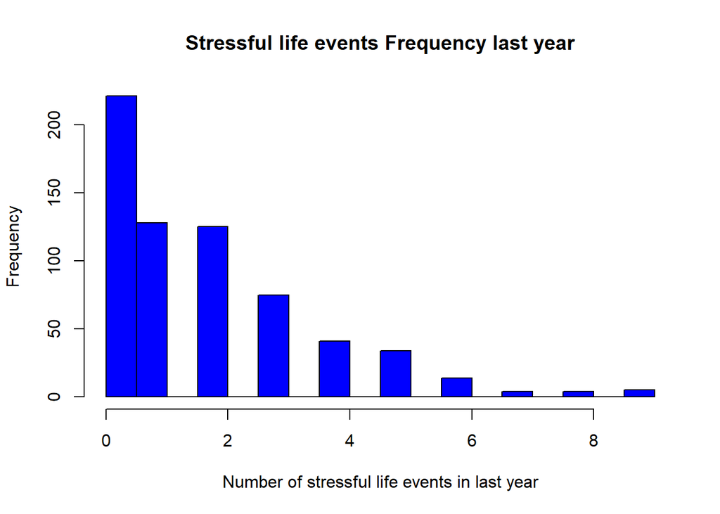

```r
hist(stress$stress, col = 'blue', breaks = 20, xlab = "Number of stressful life events in last year", main = "Stressful life events Frequency last year")
```

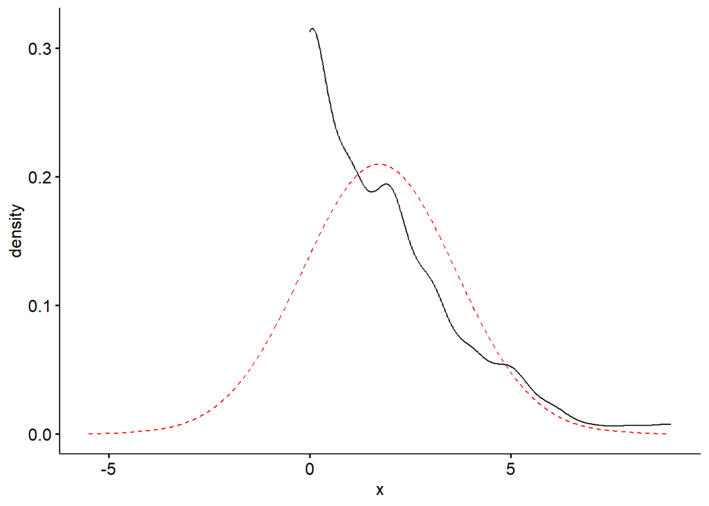

```r
ggpubr::ggdensity(stress$stress) +
  stat_overlay_normal_density(color = "red", lty = "dashed")
```

Most of the people in the sample had experienced 0-2 stressful life events in the last year. Very few people experienced 4-6 stressful life events.

From the other graph, we can see that data is skewed.

3. Conduct a Poisson regression analysis of `stress` regressed on all other variables in this data set (except `newid`). Assess overdispersion. If overdispersion is present, conduct both an overdispersed and a negative binomial regression analysis. Present the results of each of these 3 models in a single table using the `tbl_merge()` function (include incident rate ratios (IRRs) and their 95% CIs in this table).

```r
sz.poisson.1 <- glm(stress ~ age + cohes + esteem + grades + sattach, family = poisson(log), data = stress)
summ(sz.poisson.1, confint = TRUE, exp = TRUE)
```

```
## MODEL INFO:
## Observations: 651
## Dependent Variable: stress
## Type: Generalized linear model
##   Family: poisson
##   Link function: log
##
## MODEL FIT:
## χ²(5) = 104.36, p = 0.00
## Pseudo-R² (Cragg-Uhler) = 0.15
## Pseudo-R² (McFadden) = 0.04
## AIC = 2419.21, BIC = 2446.08
##
## Standard errors: MLE
## ------------------------------------------------------------
##                     exp(Est.)   2.5%   97.5%   z val.      p
## ----------------- ----------- ------ ------- -------- ------
## (Intercept)             15.00   6.31   35.62     6.13   0.00
## age                      1.00   0.95    1.06     0.07   0.94
## cohes                    0.99   0.98    0.99    -4.47   0.00
## esteem                   0.98   0.96    0.99    -2.95   0.00
## grades                   0.98   0.96    1.00    -2.38   0.02
## sattach                  0.98   0.97    1.00    -2.81   0.00
## ------------------------------------------------------------
```

```r
exp(coef(sz.poisson.1))
```

```
## (Intercept)         age       cohes      esteem      grades     sattach
##  14.9964119   1.0020596   0.9871653   0.9765926   0.9767542   0.9837101
```

```r
exp(confint(sz.poisson.1))
```

```
##                 2.5 %     97.5 %
## (Intercept) 6.3018958 35.5633172
## age         0.9471503  1.0601788
## cohes       0.9816005  0.9927951
## esteem      0.9613151  0.9920926
## grades      0.9580551  0.9959109
## sattach     0.9725600  0.9950714
```

```r
performance::check_overdispersion(sz.poisson.1)
```

```
## # Overdispersion test
##
##        dispersion ratio =    1.781
##   Pearson's Chi-Squared = 1148.810
##                 p-value =  < 0.001
```

```
## Overdispersion detected.
```

```r
dp <- sum(residuals(sz.poisson.1, type = 'pearson')^2)/sz.poisson.1$df.res
dp
```

```
## [1] 1.7811
```

```r
summary(sz.poisson.1)
```

```
##
## Call:
## glm(formula = stress ~ age + cohes + esteem + grades + sattach,
##     family = poisson(log), data = stress)
##
## Deviance Residuals:
##     Min       1Q   Median       3Q      Max
## -2.7094  -1.5974  -0.2926   0.7089   3.6445
##
## Coefficients:
##              Estimate Std. Error z value Pr(>|z|)
## (Intercept)  2.707811   0.441410   6.134 8.55e-10 ***
## age          0.002057   0.028754   0.072  0.94296
## cohes       -0.012918   0.002893  -4.466 7.99e-06 ***
## esteem      -0.023686   0.008040  -2.946  0.00322 **
## grades      -0.023520   0.009886  -2.379  0.01735 *
## sattach     -0.016424   0.005838  -2.813  0.00490 **
## ---
## Signif. codes:  0 '***' 0.001 '**' 0.01 '*' 0.05 '.' 0.1 ' ' 1
##
## (Dispersion parameter for poisson family taken to be 1)
##
##     Null deviance: 1349.8  on 650  degrees of freedom
## Residual deviance: 1245.4  on 645  degrees of freedom
## AIC: 2419.2
##
## Number of Fisher Scoring iterations: 5
```

```r
summary(sz.poisson.1, dispersion = dp)
```

```
##
## Call:
## glm(formula = stress ~ age + cohes + esteem + grades + sattach,
##     family = poisson(log), data = stress)
##
## Deviance Residuals:
##     Min       1Q   Median       3Q      Max
## -2.7094  -1.5974  -0.2926   0.7089   3.6445
##
## Coefficients:
##              Estimate Std. Error z value Pr(>|z|)
## (Intercept)  2.707811   0.589097   4.597  4.3e-06 ***
## age          0.002057   0.038375   0.054  0.95724
## cohes       -0.012918   0.003861  -3.346  0.00082 ***
## esteem      -0.023686   0.010730  -2.207  0.02728 *
## grades      -0.023520   0.013194  -1.783  0.07464 .
## sattach     -0.016424   0.007791  -2.108  0.03502 *
## ---
## Signif. codes:  0 '***' 0.001 '**' 0.01 '*' 0.05 '.' 0.1 ' ' 1
##
## (Dispersion parameter for poisson family taken to be 1.7811)
##
##     Null deviance: 1349.8  on 650  degrees of freedom
## Residual deviance: 1245.4  on 645  degrees of freedom
## AIC: 2419.2
##
## Number of Fisher Scoring iterations: 5
```

```r
sz.poisson.2 <- glm(stress ~ age + cohes + esteem + grades + sattach,
                    family = quasipoisson(log), data = stress)
summ(sz.poisson.2, confint = TRUE, exp = TRUE)
```

```
## Note: Pseudo-R2 for quasibinomial/quasipoisson families is calculated by
## refitting the fitted and null models as binomial/poisson.
```

```
## MODEL INFO:
## Observations: 651
## Dependent Variable: stress
## Type: Generalized linear model
##   Family: quasipoisson
##   Link function: log
##
## MODEL FIT:
## χ²(5) = 104.36, p = 0.00
## Pseudo-R² (Cragg-Uhler) = 0.15
## Pseudo-R² (McFadden) = 0.04
## AIC =  NA, BIC =  NA
##
## Standard errors: MLE
## ------------------------------------------------------------
##                     exp(Est.)   2.5%   97.5%   t val.      p
## ----------------- ----------- ------ ------- -------- ------
## (Intercept)             15.00   4.73   47.58     4.60   0.00
## age                      1.00   0.93    1.08     0.05   0.96
## cohes                    0.99   0.98    0.99    -3.35   0.00
## esteem                   0.98   0.96    1.00    -2.21   0.03
## grades                   0.98   0.95    1.00    -1.78   0.08
## sattach                  0.98   0.97    1.00    -2.11   0.04
## ------------------------------------------------------------
##
## Estimated dispersion parameter = 1.78
```

```r
anova(sz.poisson.1, sz.poisson.2, dispersion = dp, test = 'F')
```

```
## Analysis of Deviance Table
##
## Model 1: stress ~ age + cohes + esteem + grades + sattach
## Model 2: stress ~ age + cohes + esteem + grades + sattach
##   Resid. Df Resid. Dev Df Deviance F Pr(>F)
## 1       645     1245.4
## 2       645     1245.4  0        0
```

```r
sz.nb.1 <- glm(stress ~ age + cohes + esteem + grades + sattach, negative.binomial(5),
                  data = stress)
summ(sz.nb.1, confint = TRUE, exp = TRUE)
```

```
## MODEL INFO:
## Observations: 651
## Dependent Variable: stress
## Type: Generalized linear model
##   Family: Negative Binomial(5)
##   Link function: log
##
## MODEL FIT:
## χ²(5) = 77.25, p = 0.00
## Pseudo-R² (Cragg-Uhler) = 0.11
## Pseudo-R² (McFadden) = 0.03
## AIC = 2317.30, BIC = 2344.17
##
## Standard errors: MLE
## ------------------------------------------------------------
##                     exp(Est.)   2.5%   97.5%   t val.      p
## ----------------- ----------- ------ ------- -------- ------
## (Intercept)             16.59   5.16   53.34     4.71   0.00
## age                      1.00   0.92    1.07    -0.12   0.91
## cohes                    0.99   0.98    0.99    -3.36   0.00
## esteem                   0.98   0.96    1.00    -2.14   0.03
## grades                   0.98   0.95    1.00    -1.80   0.07
## sattach                  0.98   0.97    1.00    -2.10   0.04
## ------------------------------------------------------------
##
## Estimated dispersion parameter = 1.32
```

```r
exp(coef(sz.nb.1))
```

```
## (Intercept)         age       cohes      esteem      grades     sattach
##  16.5875970   0.9955521   0.9868844   0.9768882   0.9762550   0.9834601
```

```r
exp(confint(sz.nb.1))
```

```
##                 2.5 %     97.5 %
## (Intercept) 5.0882429 54.2147898
## age         0.9230047  1.0737807
## cohes       0.9792314  0.9946041
## esteem      0.9559791  0.9981988
## grades      0.9509263  1.0022938
## sattach     0.9683635  0.9988331
```

```r
tbl_first <- tbl_regression(sz.poisson.1, exponentiate = TRUE, conf.level = 0.95)

tbl_second <- tbl_regression(sz.poisson.2, exponentiate = TRUE, conf.level = 0.95)

tbl_third <- tbl_regression(sz.nb.1, exponentiate = TRUE, conf.level = 0.95)

tbl_merge(tbls = list(tbl_first, tbl_second, tbl_third), tab_spanner = c("First", "Second", "Third"))
```

| **Characteristic** | First **IRR**<sup>1</sup> | First **95% CI**<sup>1</sup> | First **p-value** | Second **IRR**<sup>1</sup> | Second **95% CI**<sup>1</sup> | Second **p-value** | Third **exp(Beta)** | Third **95% CI**<sup>1</sup> | Third **p-value** |
| --- | --- | --- | --- | --- | --- | --- | --- | --- | --- |
| age | 1.00 | 0.95, 1.06 | >0.9 | 1.00 | 0.93, 1.08 | >0.9 | 1.00 | 0.92, 1.07 | >0.9 |
| cohes | 0.99 | 0.98, 0.99 | <0.001 | 0.99 | 0.98, 1.0 | <0.001 | 0.99 | 0.98, 1.0 | <0.001 |
| esteem | 0.98 | 0.96, 0.99 | 0.003 | 0.98 | 0.96, 1.00 | 0.028 | 0.98 | 0.96, 1.00 | 0.033 |
| grades | 0.98 | 0.96, 1.00 | 0.017 | 0.98 | 0.95, 1.00 | 0.075 | 0.98 | 0.95, 1.00 | 0.073 |
| sattach | 0.98 | 0.97, 1.00 | 0.005 | 0.98 | 0.97, 1.00 | 0.035 | 0.98 | 0.97, 1.00 | 0.036 |

<sup>1</sup> IRR = Incidence Rate Ratio, CI = Confidence Interval

4. Describe any differences across these models in terms of the significance of individual predictor variables.

Based on the table, there are differences in terms of the significance of individual predictor variables across the three models.

The predictor variable age is not significant in any of the models, as indicated by the p-values greater than 0.9.

The predictor variable cohes is significant in all three models, with p-values less than 0.001. This suggests that higher levels of group cohesion are associated with lower odds of the outcome, regardless of which other variables are included in the model.

The predictor variable grades is significant in the first model, with a p-value of 0.017, but is not significant in the second and third models, with p-values of 0.075 and 0.073, respectively. This suggests that the association between grades and the outcome may be confounded by other variables included in the second and third models.

5. What percent of the responses to the outcome variable are 0? (Hint: can do this by recoding `stress` as a binary 0, 1 variable or turning it into a factor)

```r
table(stress$stress == 0)
```

```
##
## FALSE  TRUE
##   430   221
```

```r
(sum(stress$stress == 0) / nrow(stress)) * 100
```

```
## [1] 33.94777
```

6. Given the large number of 0s in this outcome variable, a zero-inflated regression is probably warranted. Conduct a ZINB regression model with all of the same predictors that were included in the previous exercise. Compute the IRRs and their 95% CIs. Because there are two sets of results (for the count/Poisson and logistic processes), it is not easy to compare these results to the results from a negative binomial or overdispersed model. However, the results of the ZINB model (in the count portion of the model) are largely the same as the NB and overdispersed models in terms of their pattern of significance among the predictors. Given the large number of 0s, the ZINB would be the preferred modeling approach for these data.

```r
stress.zinb.1 <- zeroinfl(stress ~ age + cohes + esteem + grades + sattach,
                   data = stress,
                   dist = "negbin")
summary(stress.zinb.1)
```

```
##
## Call:
## zeroinfl(formula = stress ~ age + cohes + esteem + grades + sattach,
##     data = stress, dist = "negbin")
##
## Pearson residuals:
##     Min      1Q  Median      3Q     Max
## -1.3002 -0.8672 -0.2151  0.5884  3.7855
##
## Count model coefficients (negbin with log link):
##              Estimate Std. Error z value Pr(>|z|)
## (Intercept)  2.342695   0.649335   3.608 0.000309 ***
## age          0.023677   0.039222   0.604 0.546070
## cohes       -0.009495   0.004308  -2.204 0.027531 *
## esteem      -0.025332   0.011529  -2.197 0.027996 *
## grades      -0.020168   0.013408  -1.504 0.132525
## sattach     -0.011062   0.008308  -1.331 0.183027
## Log(theta)   1.767963   0.351932   5.024 5.07e-07 ***
##
## Zero-inflation model coefficients (binomial with logit link):
##              Estimate Std. Error z value Pr(>|z|)
## (Intercept) -5.097277   2.397916  -2.126   0.0335 *
## age          0.152991   0.142490   1.074   0.2830
## cohes        0.018427   0.016997   1.084   0.2783
## esteem      -0.007377   0.044113  -0.167   0.8672
## grades       0.014238   0.048396   0.294   0.7686
## sattach      0.030733   0.034024   0.903   0.3664
## ---
## Signif. codes:  0 '***' 0.001 '**' 0.01 '*' 0.05 '.' 0.1 ' ' 1
##
## Theta = 5.8589
## Number of iterations in BFGS optimization: 21
## Log-likelihood: -1126 on 13 Df
```

```r
exp(coef(stress.zinb.1))
```

```
## count_(Intercept)         count_age       count_cohes      count_esteem
##      10.409252527       1.023959358       0.990549719       0.974986027
##      count_grades     count_sattach  zero_(Intercept)          zero_age
##       0.980033768       0.988999315       0.006113371       1.165314344
##        zero_cohes       zero_esteem       zero_grades      zero_sattach
##       1.018597885       0.992650081       1.014340159       1.031209668
```

```r
exp(confint(stress.zinb.1))
```

```
##                          2.5 %     97.5 %
## count_(Intercept) 2.915443e+00 37.1650345
## count_age         9.481929e-01  1.1057800
## count_cohes       9.822205e-01  0.9989496
## count_esteem      9.532028e-01  0.9972671
## count_grades      9.546151e-01  1.0061293
## count_sattach     9.730260e-01  1.0052348
## zero_(Intercept)  5.561226e-05  0.6720336
## zero_age          8.813646e-01  1.5407443
## zero_cohes        9.852244e-01  1.0531019
## zero_esteem       9.104320e-01  1.0822930
## zero_grades       9.225471e-01  1.1152665
## zero_sattach      9.646848e-01  1.1023221
```